# STA 141 Final Project

This visualization highlights differences in brain activity across regions, which may relate to behavioral outcomes or experimental conditions.

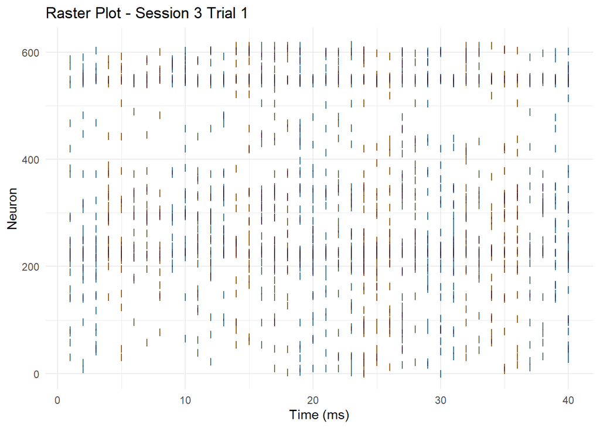

Base on the raster plot for Session 3, Trial 1 shows a more continuous sign of neuronal activity in the 200-400 and 500-600 ranges, while the 0-200 and 400-500 range exhibits sparser firing. This suggests that certain neural populations are more engaged, possibly in sensory processing or decision-making.

[output not shown]

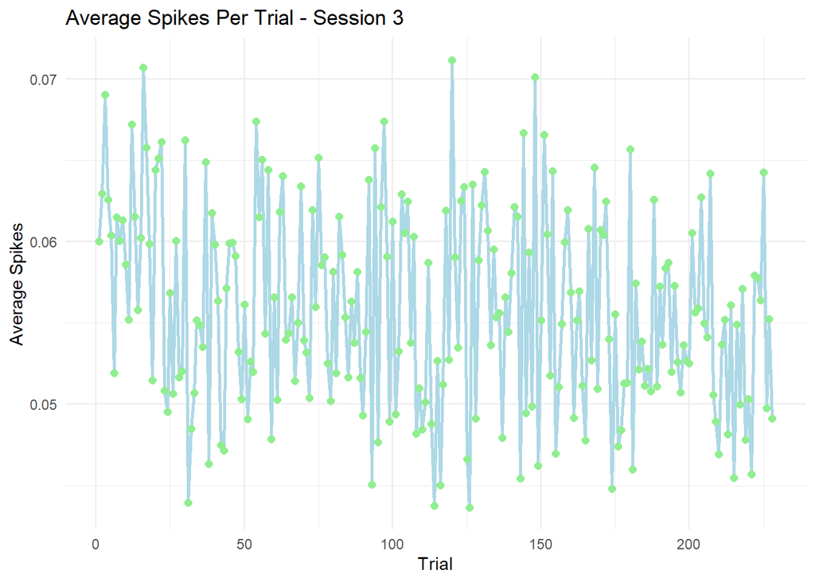

This line graph represents average spike activity per trial in Session 3, with trial numbers on the x-axis and spike counts on the y-axis. The data fluctuates with no clear trend, showing peaks around 0.07 and valleys near 0.04 at irregular intervals. Early trials exhibit higher variability, while later trials stabilize slightly, though oscillations persist. These fluctuations suggest that neural engagement varies across trials, independent of trial order, and may be influenced by specific conditions or stimuli.

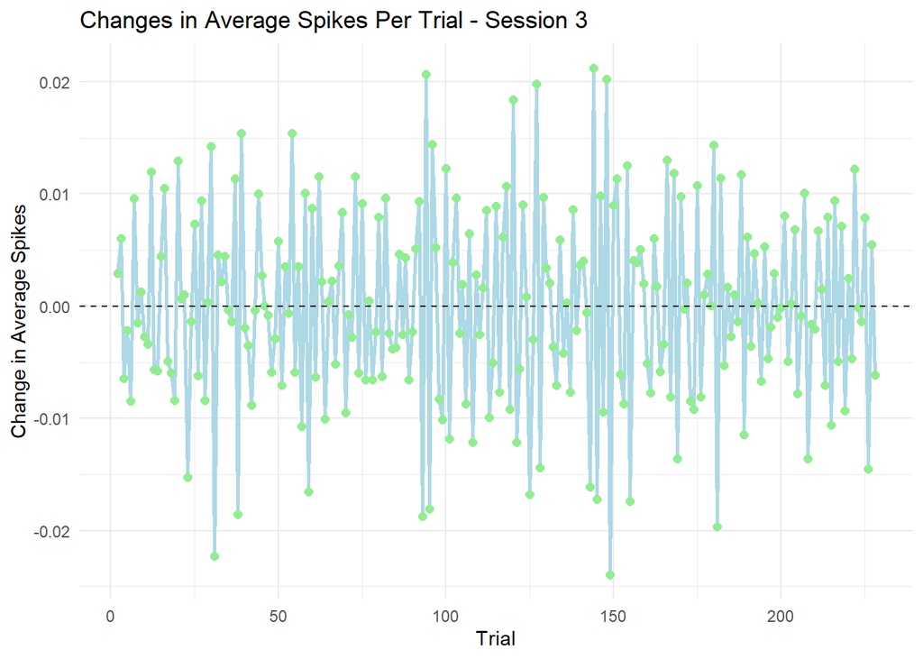

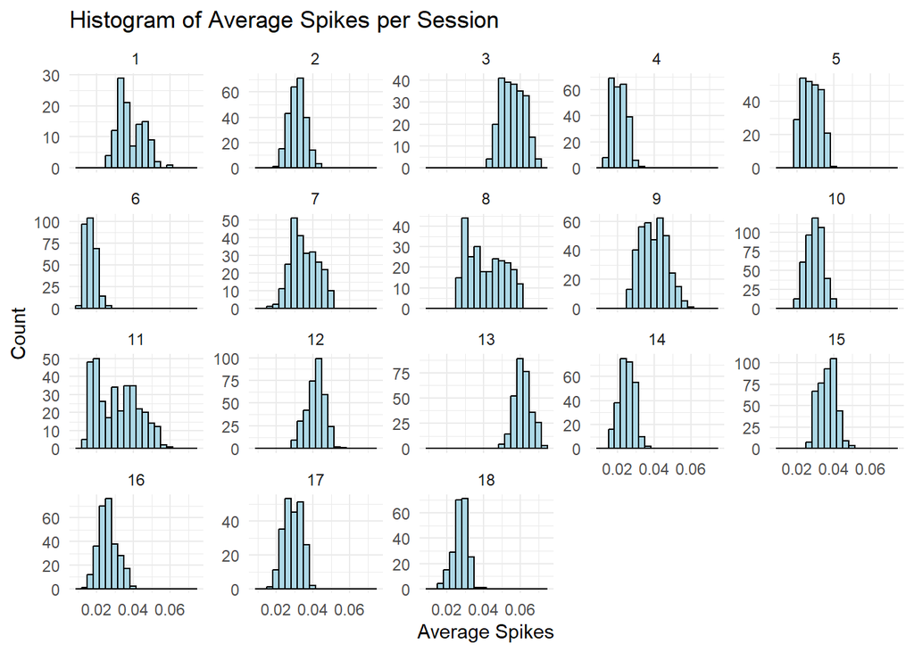

```
## [1] 1.581744
```

The result 1.581744 represents the average spike count per neuron in Trial 1 of Session 1, indicating that each neuron fired about 1.58 times on average during the trial. This measure of neural activity can be compared across trials and sessions to identify trends in neural engagement over time.